# Statistics in R

James McDermott

[figure not shown]

**Statistics in R**

# Load Tidyverse as usual

```r
library(tidyverse)
```

# Random numbers

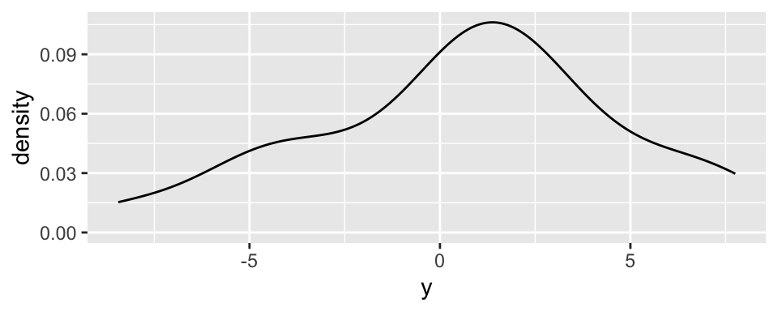

```r
x1 <- runif(20, min=0, max=2) # random uniform with bounds
x2 <- rnorm(20) # random normal with mean 0, sd 1
y <- x1 + x2 * rnorm(20, mean=5, sd=2)
ggplot(tibble(y), aes(x=y)) + geom_density()
```

# Basic statistics

```r
for (f in c(min, max, mean, median, sd, var, IQR, mad)) {
  print(f(y))
}
```

```
## [1] -8.444824
## [1] 7.75401
## [1] 0.601213
## [1] 1.098056
## [1] 4.156365
## [1] 17.27537
## [1] 4.718258
## [1] 3.527029
```

# More data summaries

```r
for (f in c(range, quantile, summary, fivenum)) {
  print(f(y))
}
```

```
## [1] -8.444824  7.754010
##        0%       25%       50%       75%      100%
## -8.444824 -1.629981  1.098056  3.088277  7.754010
##    Min. 1st Qu.  Median    Mean 3rd Qu.    Max.
## -8.4448 -1.6300  1.0981  0.6012  3.0883  7.7540
## [1] -8.444824 -2.133084  1.098056  3.269191  7.754010
```

# Correlations

```r
cor(x1, y) # get the correlation
```

```
## [1] -0.1077798
```

# Correlations: statistical test

```r
cor.test(x1, y) # run a test
```

```
##
##  Pearson's product-moment correlation
##
## data:  x1 and y
## t = -0.45995, df = 18, p-value = 0.6511
## alternative hypothesis: true correlation is not equal to 0
## 95 percent confidence interval:
##  -0.5252489  0.3515060
## sample estimates:
##        cor
## -0.1077798
```

# Correlations: using results

```r
res = cor.test(x1, y) # save the result
names(res) # see result structure
```

```
## [1] "statistic"   "parameter"   "p.value"     "estimate"    "null.value"
## [6] "alternative" "method"      "data.name"   "conf.int"
```

```r
R = res['statistic'] # extract values...
p = res['p.value'] # ...from the result
```

# Null hypothesis significance testing

# Independent 2-sample 2-sided t-test

Test whether difference in means is different from 0

```r
t.test(x1, y)
```

```
##
##  Welch Two Sample t-test
##
## data:  x1 and y
## t = 0.41727, df = 19.824, p-value = 0.681
## alternative hypothesis: true difference in means is not equal to 0
## 95 percent confidence interval:
##  -1.568716  2.352687
## sample estimates:
## mean of x mean of y
## 0.9931986 0.6012130
```

# More t-tests

The `t.test` function also has options for:

- 1-sided tests
- paired tests
- 1-sample tests.

# Regression models

The `lm` (linear model) function and variants are used for regression.

```r
df = tibble(x1, x2, y)
head(df)
```

```
## # A tibble: 6 × 3
##      x1      x2      y
##   <dbl>   <dbl>  <dbl>
## 1 0.710  1.21    6.77
## 2 1.41  -0.978  -5.05
## 3 0.666 -0.0509  0.384
## 4 1.39   0.753   3.66
## 5 1.69  -0.0695  1.67
## 6 1.65   0.598   2.91
```

# Formulas

R provides a special formula syntax involving the tilde `~`. It’s used to specify a regression model. The left-hand side is the dependent variable, `y`. The right-hand side gives the independent variables, interactions, and transformations. So, `~` means something like “is modelled as”.

```
y ~ x1 + x2
```

This says: run the formula $y = a + b_1 x_1 + b_2 x_2$

# Using a formula in a regression

```r
res <- lm(y ~ x1 + x2, data=df)
summary(res) # show results
```

```
##
## Call:
## lm(formula = y ~ x1 + x2, data = df)
##
## Residuals:
##     Min      1Q  Median      3Q     Max
## -1.7953 -0.5580 -0.1383  0.7846  1.7082
##
## Coefficients:
##             Estimate Std. Error t value Pr(>|t|)
## (Intercept)   0.3101     0.4369   0.710    0.487
## x1            0.3911     0.3792   1.032    0.317
## x2            5.4361     0.3091  17.588 2.42e-12 ***
## ---
## Signif. codes:  0 '***' 0.001 '**' 0.01 '*' 0.05 '.' 0.1 ' ' 1
##
## Residual standard error: 0.9971 on 17 degrees of freedom
## Multiple R-squared:  0.9485, Adjusted R-squared:  0.9425
## F-statistic: 156.6 on 2 and 17 DF,  p-value: 1.121e-11
```